# Social-Anxiety-Survey-script.R

David

2023-11-03

```r
library(readr)
library(tidyverse)
```

```r
library(skimr)
library(visdat)
library(plotly)
knitr::opts_chunk$set(echo = TRUE)
```

# This project is using the Social Anxiety Survey from https://www.kaggle.com/datasets/carlsonhoo/university-social-anxiety-survey/data

Download the data from the website, or the data should be included in the github repository.

If you have your pathway set this is an way to load in the csv file. I also renamed the set to data_fr to make it easier to work with.

```r
data_fr <- read_csv("Social_Anxiety_Survey_Master.csv")
```

This gives an overview of the data

```r
skim(data_fr)
```

Data summary

| Name | data_fr |
| --- | --- |
| Number of rows | 66 |
| Number of columns | 12 |
| _______________________ |  |
| Column type frequency: |  |
| character | 6 |
| numeric | 6 |
| ________________________ |  |
| Group variables | None |

**Variable type: character**

| skim_variable | n_missing | complete_rate | min | max | empty | n_unique | whitespace |
| --- | --- | --- | --- | --- | --- | --- | --- |
| Timestamp | 0 | 1 | 14 | 19 | 0 | 65 | 0 |
| Gender | 0 | 1 | 4 | 6 | 0 | 2 | 0 |
| Student | 0 | 1 | 2 | 3 | 0 | 2 | 0 |
| Age | 0 | 1 | 7 | 11 | 0 | 3 | 0 |
| Marital | 0 | 1 | 6 | 7 | 0 | 2 | 0 |
| Q1 | 0 | 1 | 25 | 25 | 0 | 5 | 0 |

**Variable type: numeric**

| skim_variable | n_missing | complete_rate | mean | sd | p0 | p25 | p50 | p75 | p100 | hist |
| --- | --- | --- | --- | --- | --- | --- | --- | --- | --- | --- |
| Q2 | 0 | 1 | 3.30 | 1.07 | 1 | 3.00 | 3 | 4 | 5 | ▁▅▇▅▃ |
| Q3 | 0 | 1 | 3.89 | 1.12 | 1 | 3.00 | 4 | 5 | 5 | ▁▂▃▆▇ |
| Q4 | 0 | 1 | 2.98 | 1.06 | 1 | 2.00 | 3 | 4 | 5 | ▂▆▇▅▂ |
| Q5 | 0 | 1 | 3.45 | 1.04 | 1 | 3.00 | 4 | 4 | 5 | ▁▅▆▇▃ |
| Q6 | 0 | 1 | 3.85 | 1.06 | 1 | 3.00 | 4 | 5 | 5 | ▁▁▅▇▆ |
| Q7 | 0 | 1 | 3.18 | 1.20 | 1 | 2.25 | 3 | 4 | 5 | ▃▂▆▇▂ |

This gives the distribution of answers for each question. 66 Respondents in total. 42 Student Respondents This filters out the non-students and gives me the number of responses by age group.

```r
filter(data_fr, Student == 'Yes') |> count(Age)
```

```
## # A tibble: 3 × 2
##   Age             n
##   <chr>       <int>
## 1 20 or below     6
## 2 21 - 30        29
## 3 31 - 40         7
```

```r
# 29/42 = 69% of students were ages 21 - 30
# 7/42 = 17% of students were ages 31 - 40
# 6/42 = 14% of students were 20 or below
```

Q1 is (“How many hours per day do you spend on social media?”)

Q2 is (“How do you feel being the center of attention”)

Q3 is (“Working while being observed?”)

Q4 is (“Talking face to face with someone you don’t know very well?”)

Q5 is (“Expressing disagreement or disapproval to someone you don’t know very well”)

Q6 is (“Are you extremely conscious of your actions when in social settings because you fear they might offend someone or you could be rejected?”)

Q7 is (“Do you feel anxious or panicky before social situations?”)

The count lets me see the distribution of answers for each column. Some questions were multiple choice while others are based off 1-5 of the Likert scale.

```r
count(data_fr, Q1)
```

```
## # A tibble: 5 × 2
##   Q1                            n
##   <chr>                     <int>
## 1 4 hours and above per day    28
## 2 Less than 1 hours per day     9
## 3 Less than 2 hours per day     8
## 4 Less than 3 hours per day    12
## 5 Less than 4 hours per day     9
```

```r
count(data_fr, Q2)
```

```
## # A tibble: 5 × 2
##      Q2     n
##   <dbl> <int>
## 1     1     2
## 2     2    13
## 3     3    25
## 4     4    15
## 5     5    11
```

```r
count(data_fr, Q3)
```

```
## # A tibble: 5 × 2
##      Q3     n
##   <dbl> <int>
## 1     1     2
## 2     2     7
## 3     3    12
## 4     4    20
## 5     5    25
```

```r
count(data_fr, Q4)
```

```
## # A tibble: 5 × 2
##      Q4     n
##   <dbl> <int>
## 1     1     4
## 2     2    19
## 3     3    23
## 4     4    14
## 5     5     6
```

```r
count(data_fr, Q5)
```

```
## # A tibble: 5 × 2
##      Q5     n
##   <dbl> <int>
## 1     1     1
## 2     2    13
## 3     3    18
## 4     4    23
## 5     5    11
```

```r
count(data_fr, Q6)
```

```
## # A tibble: 5 × 2
##      Q6     n
##   <dbl> <int>
## 1     1     3
## 2     2     3
## 3     3    15
## 4     4    25
## 5     5    20
```

```r
count(data_fr, Q7)
```

```
## # A tibble: 5 × 2
##      Q7     n
##   <dbl> <int>
## 1     1     9
## 2     2     8
## 3     3    18
## 4     4    24
## 5     5     7
```

```r
#I decided having the columns listed as Q would be easier and have the columns names listed as comments rather than replacing their names in the dataframe.
```

This gives length, class, and mode for a chosen column.

```r
summary(data_fr$Q1)
```

```
##    Length     Class      Mode
##        66 character character
```

This checks if all questions were answered for each subject , which shows 100% on all questions.

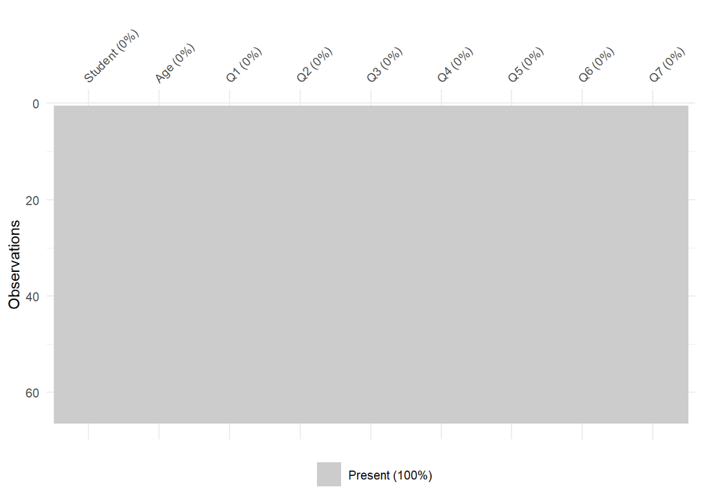

```r
data_fr %>%
  select(Student, Age, Q1, Q2, Q3, Q4, Q5, Q6, Q7) %>%
  vis_miss(cluster = TRUE)
```

This checks the beginning and end of the data. Doesn’t appear to have any errors or discrepancies.

```r
data_fr |>
  head () |>
  view()

data_fr |>
  tail () |>
  view()
```

Compared with at least one external source. There is a discrepancy from the data mentioned from the blog and what is available on kaggle.  
https://carlson-hoo.medium.com/what-type-of-social-media-users-are-more-likely-to-have-social-anxiety-disorder-65194323f8e1

I cannot find a record as to why there are 42 students available on kaggle but 69 students listed on the blog website. Perhaps the author received more data after he uploaded the set to kaggle and before the blogsite was created.

This visualizes the distribution of answers for each question and removes the non-student answers.

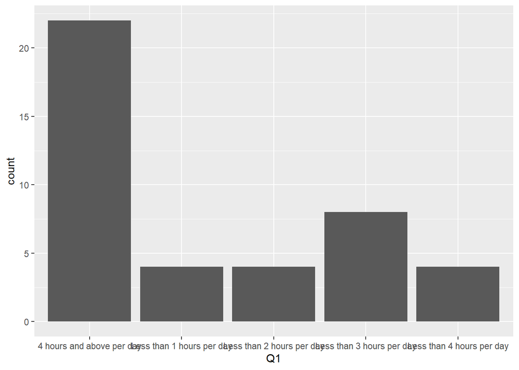

```r
data_fr |>
  filter(Student == "Yes") |>
ggplot(aes(Q1)) +
  geom_bar()
```

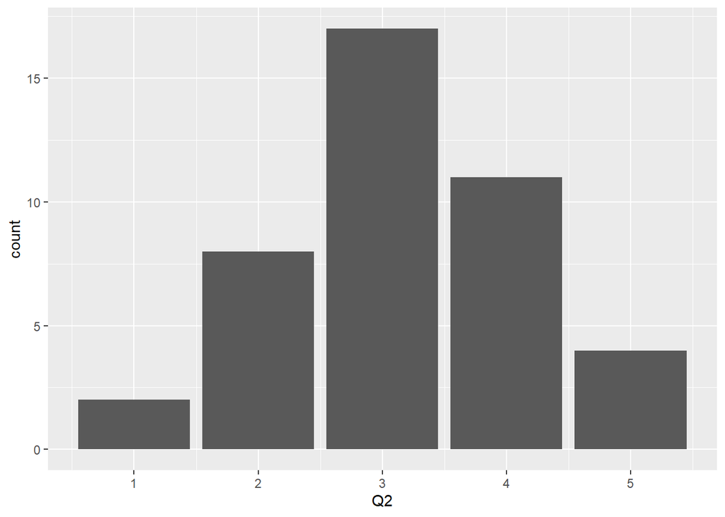

```r
data_fr |>
  filter(Student == "Yes") |>
  ggplot(aes(Q2)) +
  geom_bar()
```

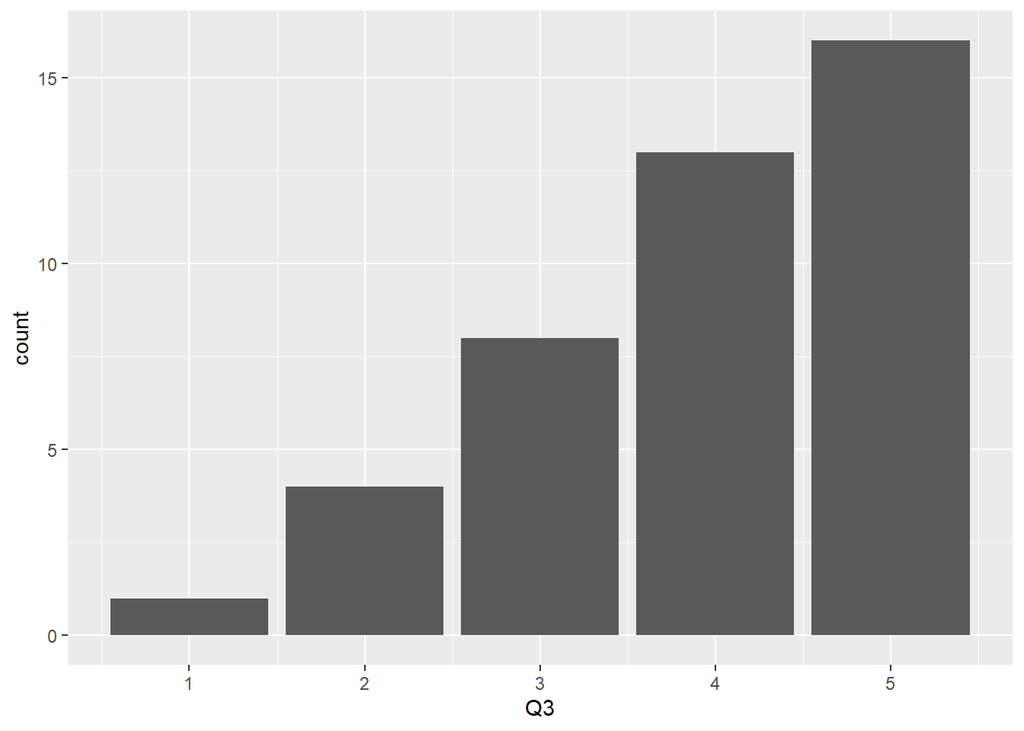

```r
data_fr |>
  filter(Student == "Yes") |>
  ggplot(aes(Q3)) +
  geom_bar()
```

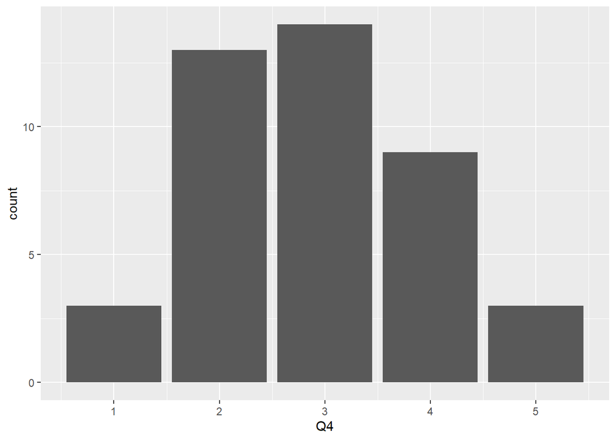

```r
data_fr |>
  filter(Student == "Yes") |>
  ggplot(aes(Q4)) +
  geom_bar()
```

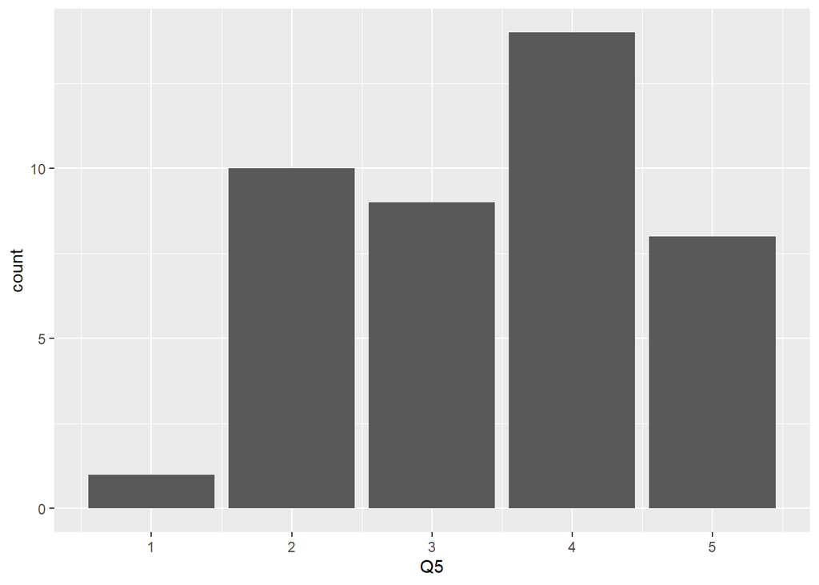

```r
data_fr |>
  filter(Student == "Yes") |>
  ggplot(aes(Q5)) +
  geom_bar()
```

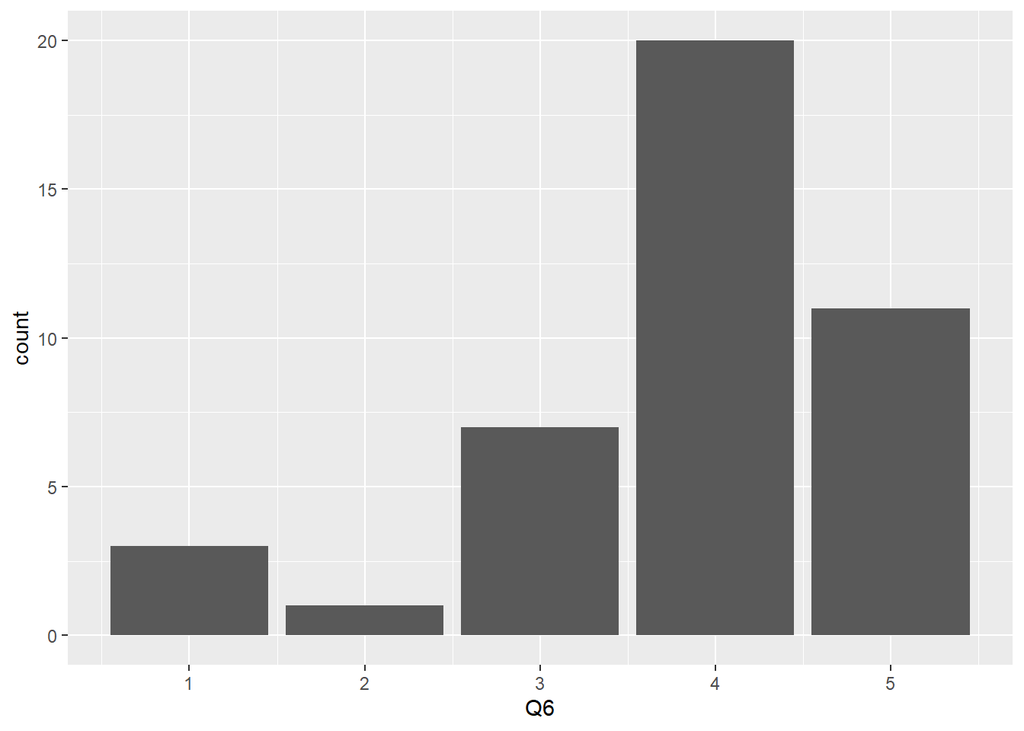

```r
data_fr |>
  filter(Student == "Yes") |>
  ggplot(aes(Q6)) +
  geom_bar()
```

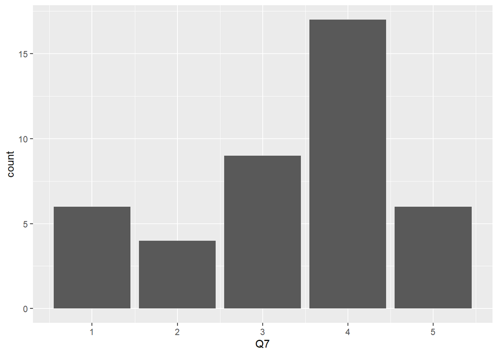

```r
data_fr |>
  filter(Student == "Yes") |>
  ggplot(aes(Q7)) +
  geom_bar()
```

This section creates colored graphs comparing variables of interest.

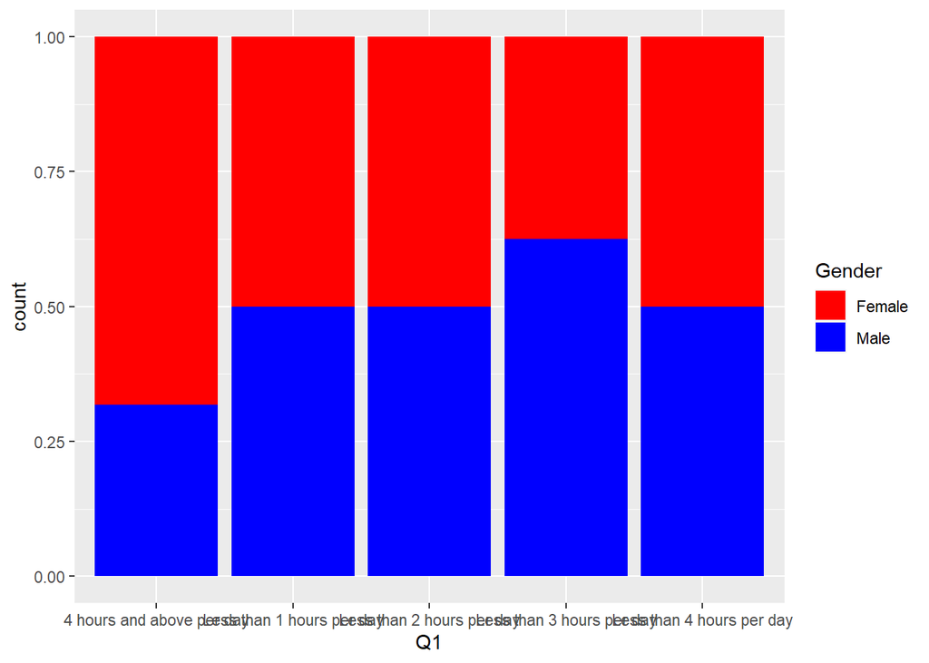

```r
data_fr |>
  filter(Student == "Yes") |>
  ggplot(aes(Q1, fill = Gender)) +
  geom_bar(position = position_fill()) +
  scale_fill_manual(values = c('red', 'blue', 'green', 'black', 'purple'))
```

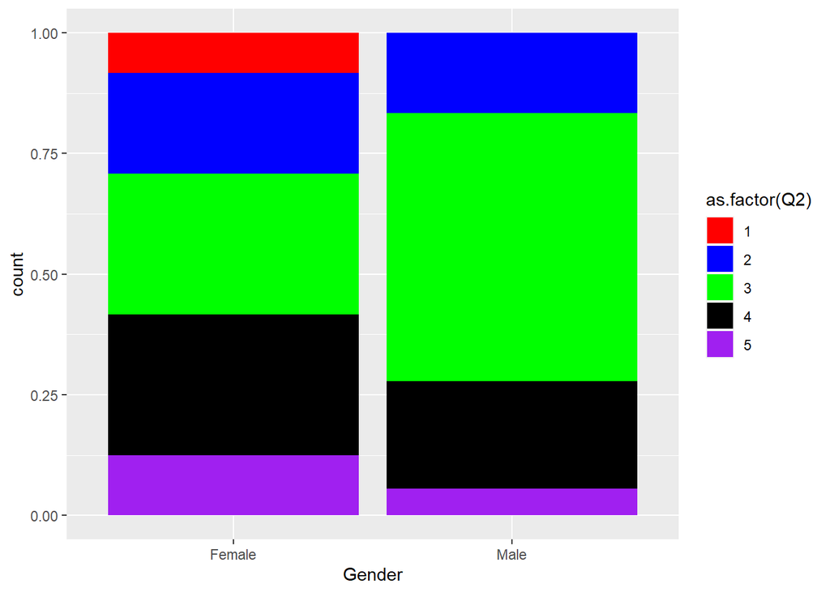

```r
data_fr |>
  filter(Student == "Yes") |>
  ggplot(aes(Gender, fill = as.factor(Q2))) +
  geom_bar(position = position_fill()) +
  scale_fill_manual(values = c('red', 'blue', 'green', 'black', 'purple'))
```

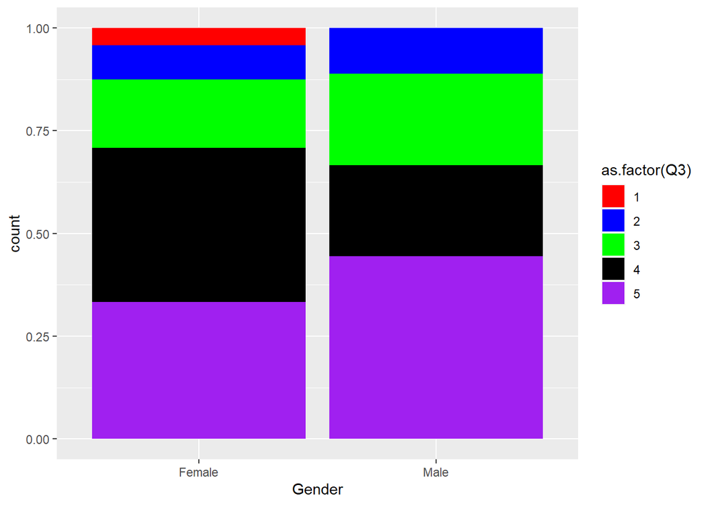

```r
data_fr |>
  filter(Student == "Yes") |>
  ggplot(aes(Gender, fill = as.factor(Q3))) +
  geom_bar(position = position_fill()) +
  scale_fill_manual(values = c('red', 'blue', 'green', 'black', 'purple'))
```

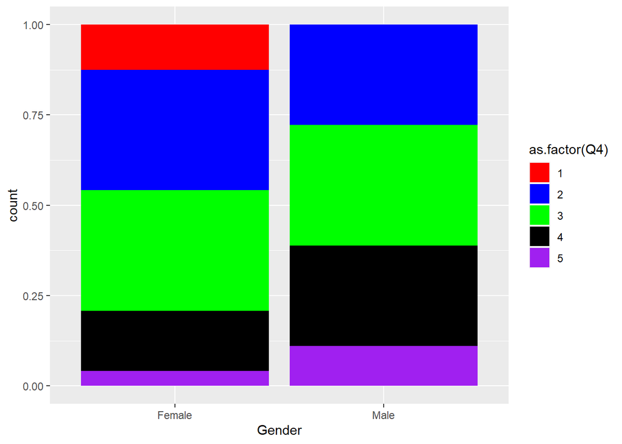

```r
data_fr |>
  filter(Student == "Yes") |>
  ggplot(aes(Gender, fill = as.factor(Q4))) +
  geom_bar(position = position_fill()) +
  scale_fill_manual(values = c('red', 'blue', 'green', 'black', 'purple'))
```

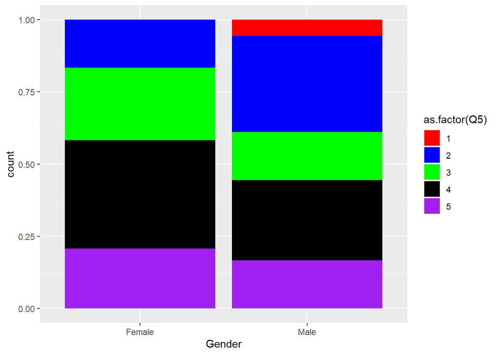

```r
data_fr |>
  filter(Student == "Yes") |>
  ggplot(aes(Gender, fill = as.factor(Q5))) +
  geom_bar(position = position_fill()) +
  scale_fill_manual(values = c('red', 'blue', 'green', 'black', 'purple'))
```

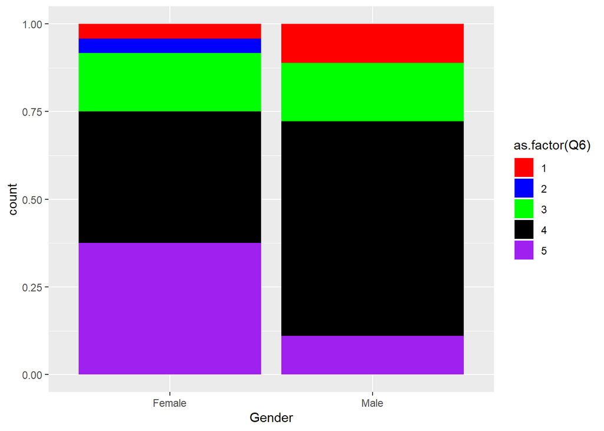

```r
data_fr |>
  filter(Student == "Yes") |>
  ggplot(aes(Gender, fill = as.factor(Q6))) +
  geom_bar(position = position_fill()) +
  scale_fill_manual(values = c('red', 'blue', 'green', 'black', 'purple'))
```

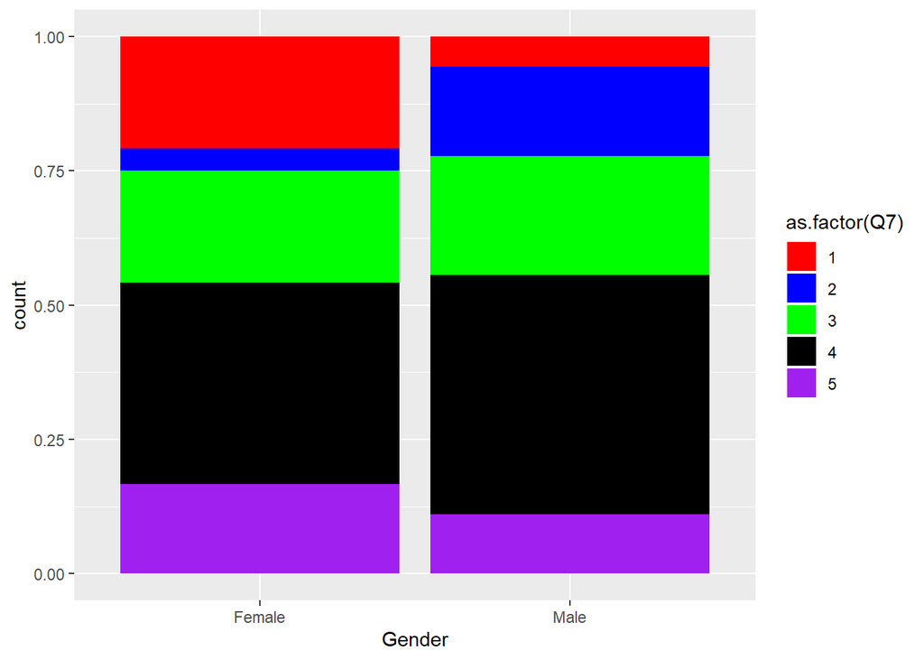

```r
data_fr |>
  filter(Student == "Yes") |>
  ggplot(aes(Gender, fill = as.factor(Q7))) +
  geom_bar(position = position_fill()) +
  scale_fill_manual(values = c('red', 'blue', 'green', 'black', 'purple'))
```

This section shows the percentages of answers between genders for each question in descending order of most stressed to least stressed.

```r
data_fr |>
  filter(Student == "Yes") |>
  count(Gender, Q1) |>
  group_by(Gender) |>
  mutate(share = n / sum(n)) |>
  ungroup()|>
  arrange(desc(Q1))|>
  mutate(share = scales::percent(share, accuracty = 1))
```

```
## # A tibble: 10 × 4
##    Gender Q1                            n share
##    <chr>  <chr>                     <int> <chr>
##  1 Female Less than 4 hours per day     2 8.3%
##  2 Male   Less than 4 hours per day     2 11.1%
##  3 Female Less than 3 hours per day     3 12.5%
##  4 Male   Less than 3 hours per day     5 27.8%
##  5 Female Less than 2 hours per day     2 8.3%
##  6 Male   Less than 2 hours per day     2 11.1%
##  7 Female Less than 1 hours per day     2 8.3%
##  8 Male   Less than 1 hours per day     2 11.1%
##  9 Female 4 hours and above per day    15 62.5%
## 10 Male   4 hours and above per day     7 38.9%
```

```r
data_fr |>
  filter(Student == "Yes") |>
  count(Gender, Q2) |>
  group_by(Gender) |>
  mutate(share = n / sum(n)) |>
  ungroup()|>
  arrange(desc(Q2))|>
  mutate(share = scales::percent(share, accuracty = 1))
```

```
## # A tibble: 9 × 4
##   Gender    Q2     n share
##   <chr>  <dbl> <int> <chr>
## 1 Female     5     3 12.5%
## 2 Male       5     1 5.6%
## 3 Female     4     7 29.2%
## 4 Male       4     4 22.2%
## 5 Female     3     7 29.2%
## 6 Male       3    10 55.6%
## 7 Female     2     5 20.8%
## 8 Male       2     3 16.7%
## 9 Female     1     2 8.3%
```

```r
data_fr |>
  filter(Student == "Yes") |>
  count(Gender, Q3) |>
  group_by(Gender) |>
  mutate(share = n / sum(n)) |>
  ungroup()|>
  arrange(desc(Q3))|>
  mutate(share = scales::percent(share, accuracty = 1))
```

```
## # A tibble: 9 × 4
##   Gender    Q3     n share
##   <chr>  <dbl> <int> <chr>
## 1 Female     5     8 33.3%
## 2 Male       5     8 44.4%
## 3 Female     4     9 37.5%
## 4 Male       4     4 22.2%
## 5 Female     3     4 16.7%
## 6 Male       3     4 22.2%
## 7 Female     2     2 8.3%
## 8 Male       2     2 11.1%
## 9 Female     1     1 4.2%
```

```r
data_fr |>
  filter(Student == "Yes") |>
  count(Gender, Q4) |>
  group_by(Gender) |>
  mutate(share = n / sum(n)) |>
  ungroup()|>
  arrange(desc(Q4))|>
  mutate(share = scales::percent(share, accuracty = 1))
```

```
## # A tibble: 9 × 4
##   Gender    Q4     n share
##   <chr>  <dbl> <int> <chr>
## 1 Female     5     1 4.2%
## 2 Male       5     2 11.1%
## 3 Female     4     4 16.7%
## 4 Male       4     5 27.8%
## 5 Female     3     8 33.3%
## 6 Male       3     6 33.3%
## 7 Female     2     8 33.3%
## 8 Male       2     5 27.8%
## 9 Female     1     3 12.5%
```

```r
data_fr |>
  filter(Student == "Yes") |>
  count(Gender, Q5) |>
  group_by(Gender) |>
  mutate(share = n / sum(n)) |>
  ungroup()|>
  arrange(desc(Q5))|>
  mutate(share = scales::percent(share, accuracty = 1))
```

```
## # A tibble: 9 × 4
##   Gender    Q5     n share
##   <chr>  <dbl> <int> <chr>
## 1 Female     5     5 20.8%
## 2 Male       5     3 16.7%
## 3 Female     4     9 37.5%
## 4 Male       4     5 27.8%
## 5 Female     3     6 25.0%
## 6 Male       3     3 16.7%
## 7 Female     2     4 16.7%
## 8 Male       2     6 33.3%
## 9 Male       1     1 5.6%
```

```r
data_fr |>
  filter(Student == "Yes") |>
  count(Gender, Q6) |>
  group_by(Gender) |>
  mutate(share = n / sum(n)) |>
  ungroup()|>
  arrange(desc(Q6))|>
  mutate(share = scales::percent(share, accuracty = 1))
```

```
## # A tibble: 9 × 4
##   Gender    Q6     n share
##   <chr>  <dbl> <int> <chr>
## 1 Female     5     9 37.5%
## 2 Male       5     2 11.1%
## 3 Female     4     9 37.5%
## 4 Male       4    11 61.1%
## 5 Female     3     4 16.7%
## 6 Male       3     3 16.7%
## 7 Female     2     1 4.2%
## 8 Female     1     1 4.2%
## 9 Male       1     2 11.1%
```

```r
data_fr |>
  filter(Student == "Yes") |>
  count(Gender, Q7) |>
  group_by(Gender) |>
  mutate(share = n / sum(n)) |>
  ungroup()|>
  arrange(desc(Q7))|>
  mutate(share = scales::percent(share, accuracty = 1))
```

```
## # A tibble: 10 × 4
##    Gender    Q7     n share
##    <chr>  <dbl> <int> <chr>
##  1 Female     5     4 16.7%
##  2 Male       5     2 11.1%
##  3 Female     4     9 37.5%
##  4 Male       4     8 44.4%
##  5 Female     3     5 20.8%
##  6 Male       3     4 22.2%
##  7 Female     2     1 4.2%
##  8 Male       2     3 16.7%
##  9 Female     1     5 20.8%
## 10 Male       1     1 5.6%
```